# Project 2: Data Mining, Classification, Prediction

SDS322E

# Mining, Classification, Prediction

## Lindsey King lkk497

### Introduction

The data set that I have chosen for this project is `Fatality`. This data set contains statistics about drunk drivers and traffic laws from the years 1982 to 1988 in 48 different states. One observation is a set of statistics from one specific year in one specific state. For this project I decided to just use the statictis for each of th 48 states from the year 1988. Drunk driving is a very serious crime that causes thousands of deaths each year. I chose this data set to analyze to see what different aspects have affects on drunk driving statistics and if there is a way we can effectively decrease drunk driving. This data set is from the package `Edcat` and I found it on the website https://vincentarelbundock.github.io/Rdatasets/datasets.html. The data set has 336 observations in total. The variable `state` is the state ID code for each observation. The states are alphabetically coded so 1 is Alabama and 56 is Wyoming (some numbers are skipped like 7 that’s why there is 56). The variable `year` contains the year of each observation. The variable `mrall` measures the traffic fatality rate (deaths per 10,000 people). The variable `beertax` measures the tax on a case of beer. The variable `mlda` is the minimum legal drinking age. The variable `jaild` is a binary measure of whether or not drunk driving had a mandatory jail sentence in a state. The variable `comserd` is a binary measure of whether or not drunk driving had a mandatory community service sentence in a state. The variable `vmiles` measures the average miles per driver. The variable `unrate` measures the unemployment rate. The variable `perinc` measured the per capita personal income. I removed one extraneous variable. In this data set there are 34 observations that did not have a mandatory jail sentence and 14 observations that did have a mandatory jail sentence. There 38 observations that did not have a mandatory community service sentence and 10 observations that did have a mandatory community service sentence.

```r
library(tidyverse)

library(readr)
Fatality <- read_csv("Fatality.csv")

Fatality <- Fatality %>% filter(year == 1988)
head(Fatality)
```

```
## # A tibble: 6 x 11
##      X1 state  year mrall beertax  mlda jaild comserd vmiles unrate perinc
##   <dbl> <dbl> <dbl> <dbl>   <dbl> <dbl> <chr> <chr>    <dbl>  <dbl>  <dbl>
## 1     7     1  1988  2.49  1.50      21 no    no        9.67   7.20 12369.
## 2    14     4  1988  2.71  0.346     21 yes   yes       9.82   6.30 14408.
## 3    21     5  1988  2.55  0.525     21 no    no        8.02   7.70 11760.
## 4    28     6  1988  1.90  0.0866    21 no    no        8.53   5.30 18049.
## 5    35     8  1988  1.51  0.173     21 no    yes       8.38   6.40 15845.
## 6    42     9  1988  1.50  0.217     21 yes   yes       8.06   3    22193.
```

```r
Fatality %>% group_by(jaild) %>% summarize(n())
```

```
## # A tibble: 2 x 2
##   jaild `n()`
##   <chr> <int>
## 1 no       34
## 2 yes      14
```

```r
Fatality %>% group_by(comserd) %>% summarize(n())
```

```
## # A tibble: 2 x 2
##   comserd `n()`
##   <chr>   <int>
## 1 no         38
## 2 yes        10
```

### Cluster Analysis

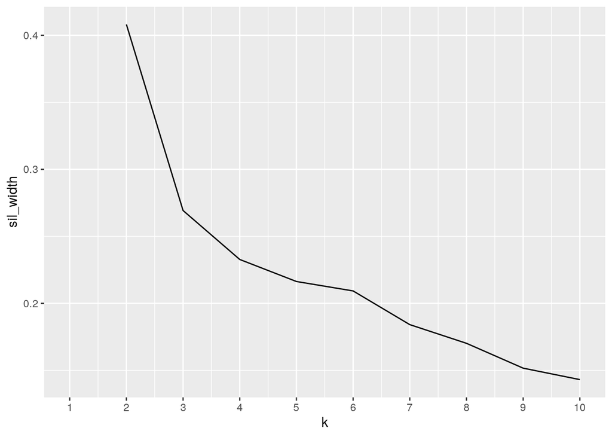

```r
library(cluster)
Fat_clust <- Fatality %>% mutate_if(is.character, as.factor) %>%
    select(X1, mrall, beertax, vmiles, unrate, perinc, jaild)
gower <- daisy(Fat_clust, metric = "gower")

sil_width <- vector()
for (i in 2:10) {
    pam_fit <- pam(gower, diss = TRUE, k = i)
    sil_width[i] <- pam_fit$silinfo$avg.width
}

ggplot() + geom_line(aes(x = 1:10, y = sil_width)) + scale_x_continuous(name = "k",
    breaks = 1:10)
```

```r
pam <- pam(gower, k = 2, diss = T)
pam
```

```
## Medoids:
##      ID
## [1,] 23 23
## [2,] 35 35
## Clustering vector:
##  [1] 1 2 1 1 1 2 1 1 1 1 1 1 1 2 1 2 2 1 1 1 1 1 1 2 1 2 1 1 1 1 1 1 1 1 2 1 1 2
## [39] 1 2 1 2 1 1 2 2 1 2
## Objective function:
##     build      swap
## 0.1567406 0.1567406
##
## Available components:
## [1] "medoids"    "id.med"     "clustering" "objective"  "isolation"
## [6] "clusinfo"   "silinfo"    "diss"       "call"
```

```r
Fatality %>% slice(pam$id.med)
```

```
## # A tibble: 2 x 11
##      X1 state  year mrall beertax  mlda jaild comserd vmiles unrate perinc
##   <dbl> <dbl> <dbl> <dbl>   <dbl> <dbl> <chr> <chr>    <dbl>  <dbl>  <dbl>
## 1   161    29  1988  2.15   0.280    21 no    no        8.86   5.70 14872.
## 2   245    41  1988  2.45   0.182    21 yes   yes       9.11   5.80 14326.
```

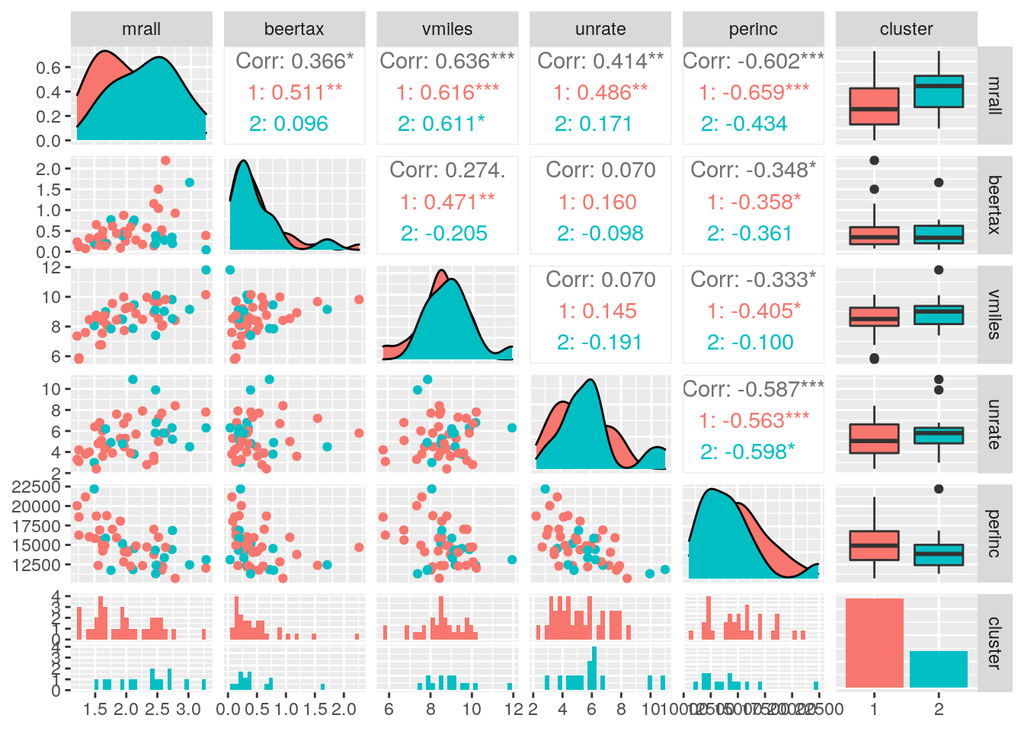

```r
library(GGally)
Fat_clust %>% mutate(cluster = as.factor(pam$clustering)) %>%
    ggpairs(columns = c(2:6, 8), aes(color = cluster))
```

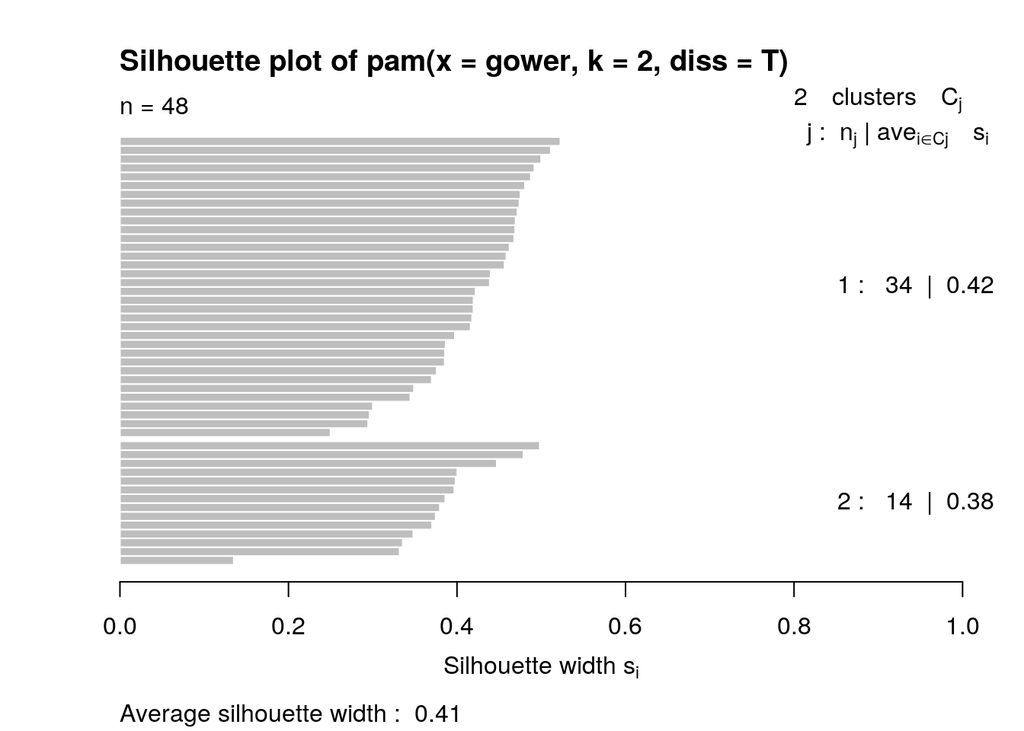

```r
plot(pam, which = 2)
```

```r
pam$silinfo$avg.width
```

```
## [1] 0.4081087
```

### Dimensionality Reduction with PCA

```r
Fat_num <- Fatality %>% select(mrall, beertax, vmiles, unrate,
    perinc)
pca <- princomp(Fat_num, scale = T, center = T, cor = T)
summary(pca, loadings = T)
```

```
## Importance of components:
##                           Comp.1    Comp.2    Comp.3     Comp.4    Comp.5
## Standard deviation     1.5976622 1.0404332 0.8814900 0.57179567 0.5108811
## Proportion of Variance 0.5105049 0.2165002 0.1554049 0.06539006 0.0521999
## Cumulative Proportion  0.5105049 0.7270051 0.8824100 0.94780010 1.0000000
##
## Loadings:
##         Comp.1 Comp.2 Comp.3 Comp.4 Comp.5
## mrall    0.551  0.121  0.240  0.180  0.769
## beertax  0.336  0.405 -0.814  0.223 -0.102
## vmiles   0.413  0.508  0.511        -0.552
## unrate   0.377 -0.692         0.544 -0.288
## perinc  -0.520  0.291  0.132  0.786  0.101
```

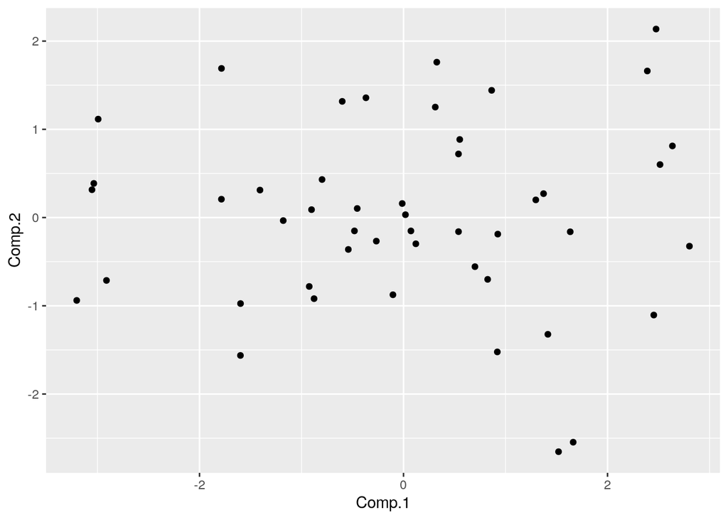

```r
pcascore_df <- as.data.frame(pca$scores)
pcascore_df %>% ggplot(aes(x = Comp.1, y = Comp.2)) + geom_point()
```

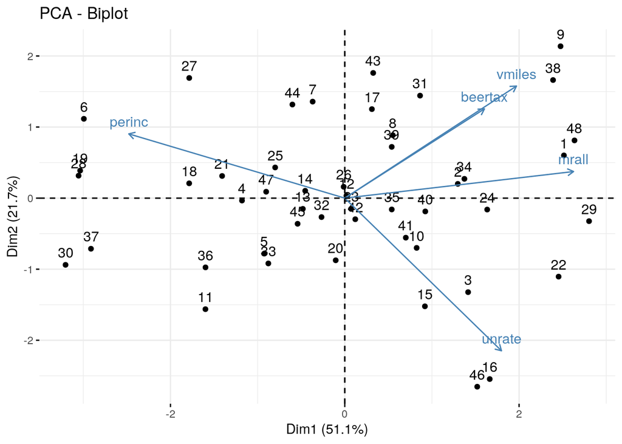

```r
library(factoextra)
fviz_pca_biplot(pca)
```

The cumulative proportion of variance is less than 0.80 up to the second principal component (PC), therefore the first and second principal components will be kept (PC1 & PC2). Two principal components can summarize 73% of the total variability. The higher a PC mean the higher amount of variation, and a lower PC means a lower amount of variation. All of the loadings in PC1 have a similar sign and magnitude expect for `perinc`. This means that the higher a state’s traffic fatality rate, beer tax, average miles per driver and unemployment rate, the lower their per capita personal income will be. PC2 suggest that the higher a state’s beer tax, average miles per driver, per capita personal income, and traffic fatality rate, the lower their unemployment rate. PC1 and PC2 are uncorrelated.

### Linear Classifier

```r
Fatality$jaild <- ifelse(Fatality$jaild == "yes", 1, 0)
Fat_class <- Fatality %>% select(jaild, mrall, beertax, vmiles,
    unrate, perinc) %>% na.omit()
```

```r
# linear classifier code here
logistic_fit <- glm(jaild ~ ., data = Fat_class, family = "binomial")

prob_reg <- predict(logistic_fit, type = "response")
prob_reg %>% round(3)
```

```
##     1     2     3     4     5     6     7     8     9    10    11    12    13
## 0.295 0.584 0.431 0.318 0.185 0.171 0.439 0.324 0.231 0.410 0.196 0.274 0.180
##    14    15    16    17    18    19    20    21    22    23    24    25    26
## 0.221 0.413 0.351 0.211 0.214 0.097 0.282 0.111 0.460 0.337 0.480 0.109 0.580
##    27    28    29    30    31    32    33    34    35    36    37    38    39
## 0.106 0.153 0.772 0.091 0.216 0.116 0.158 0.220 0.468 0.142 0.065 0.329 0.185
##    40    41    42    43    44    45    46    47    48
## 0.483 0.322 0.103 0.280 0.181 0.235 0.476 0.172 0.825
```

```r
class_diag(prob_reg, Fat_class$jaild, positive = 1)
```

```
##          acc   sens   spec  ppv     f1     ba    auc
## Metrics 0.75 0.2143 0.9706 0.75 0.3333 0.5924 0.7458
```

```r
prob_reg <- ifelse(prob_reg > 0.5, "yes", "no")
Fatality$jaild <- ifelse(Fatality$jaild == 1, "yes", "no")
table(actual = Fatality$jaild, predicted = prob_reg)
```

```
##       predicted
## actual no yes
##    no  33   1
##    yes 11   3
```

```r
# cross-validation of linear classifier here
set.seed(1234)
k = 5  #choose number of folds

data <- Fat_class[sample(nrow(Fat_class)), ]  #randomly order rows
folds <- cut(seq(1:nrow(Fat_class)), breaks = k, labels = F)  #create 10 folds

diags <- NULL
for (i in 1:k) {
    ## Create training and test sets
    train <- data[folds != i, ]
    test <- data[folds == i, ]
    truth <- test$jaild

    ## Train model on training set
    fit <- glm(jaild ~ ., data = train, family = "binomial")
    probs <- predict(fit, newdata = test, type = "response")

    ## Test model on test set (save all k results)
    diags <- rbind(diags, class_diag(probs, truth, positive = 1))
}
summarize_all(diags, mean)
```

```
##       acc sens    spec ppv  f1      ba     auc
## 1 0.66222  0.1 0.88142 NaN NaN 0.49072 0.44308
```

The AUC from the linear regression classifier is 0.75, which means in-sample the model is performing fair. The CV AUC is 0.44 which is even lower, meaning the model is performing bad out of sample. The model is predicting new observations poorly per the CV AUC. Since there is a significant difference between the AUC values this model does show signs of overfitting.

### Non-Parametric Classifier

```r
Fatality$jaild <- ifelse(Fatality$jaild == "yes", 1, 0)
```

```r
library(caret)
# non-parametric classifier code here
knn_fit <- knn3(jaild ~ ., data = Fat_class)

prob_knn <- predict(knn_fit, newdata = Fat_class)[, 2]
prob_knn %>% round(3)
```

```
##  [1] 0.4 0.6 0.4 0.0 0.2 0.2 0.2 0.2 0.2 0.0 0.2 0.6 0.2 0.2 0.2 0.4 0.4 0.0 0.0
## [20] 0.2 0.2 0.6 0.0 0.4 0.2 0.2 0.0 0.2 0.2 0.0 0.2 0.2 0.2 0.6 0.6 0.2 0.2 0.4
## [39] 0.0 0.4 0.2 0.6 0.2 0.2 0.2 0.6 0.2 0.6
```

```r
class_diag(prob_knn, Fat_class$jaild, positive = 1)
```

```
##          acc   sens   spec   ppv     f1     ba   auc
## Metrics 0.75 0.3571 0.9118 0.625 0.4545 0.6345 0.812
```

```r
prob_knn <- ifelse(prob_knn > 0.5, "yes", "no")
table(actual = Fatality$jaild, predicted = prob_knn)
```

```
##       predicted
## actual no yes
##      0 31   3
##      1  9   5
```

```r
# cross-validation of np classifier here
set.seed(1234)
k = 5  #choose number of folds

data <- Fat_class[sample(nrow(Fat_class)), ]  #randomly order rows
folds <- cut(seq(1:nrow(Fat_class)), breaks = k, labels = F)  #create 10 folds

diags <- NULL
for (i in 1:k) {
    ## Create training and test sets
    train <- data[folds != i, ]
    test <- data[folds == i, ]
    truth <- test$jaild

    ## Train model on training set
    fit <- knn3(jaild ~ ., data = train)
    probs <- predict(fit, newdata = test)[, 2]

    ## Test model on test set (save all k results)
    diags <- rbind(diags, class_diag(probs, truth, positive = 1))
}
summarize_all(diags, mean)
```

```
##       acc sens spec ppv  f1   ba     auc
## 1 0.68444    0 0.96 NaN NaN 0.48 0.47858
```

The AUC from the k-nearest-neighbors classifier is 0.81, meaning the in-sample model is performing good. The CV AUC is 0.48, which means the out of sample model is performing badly. The model is predicting new observations poorly per the CV AUC. Since there is a significant difference between the AUC values this model does show signs of overfitting. The nonparametric model performed better in comparison to the linear model in its cross-validation performance, but not by much. only by 0.04.

### Regression/Numeric Prediction

```r
# regression model code here
linear_fit <- lm(mrall ~ vmiles + beertax, data = Fat_class)

prob_linear <- predict(linear_fit, newdata = Fat_class)
prob_linear %>% round(3)
```

```
##     1     2     3     4     5     6     7     8     9    10    11    12    13
## 2.610 2.361 1.921 1.949 1.930 1.854 2.279 2.188 2.822 1.892 1.485 2.171 1.831
##    14    15    16    17    18    19    20    21    22    23    24    25    26
## 2.011 1.957 1.921 2.368 1.862 1.667 2.010 1.988 2.125 2.087 2.435 2.007 1.975
##    27    28    29    30    31    32    33    34    35    36    37    38    39
## 2.151 1.693 2.460 1.214 2.322 2.044 1.749 2.540 2.129 1.507 1.248 2.509 2.284
##    40    41    42    43    44    45    46    47    48
## 2.130 2.237 1.933 2.460 2.356 2.102 1.717 2.020 2.827
```

```r
mean((Fat_class$mrall - prob_linear)^2)
```

```
## [1] 0.1476723
```

```r
# cross-validation of regression model here
set.seed(1234)
k = 5  #choose number of folds

data <- Fat_class[sample(nrow(Fat_class)), ]  #randomly order rows
folds <- cut(seq(1:nrow(Fat_class)), breaks = k, labels = F)  #create folds

diags <- NULL
for (i in 1:k) {
    train <- data[folds != i, ]
    test <- data[folds == i, ]

    ## Fit linear regression model to training set
    fit <- lm(mrall ~ vmiles + beertax, data = train)

    ## Get predictions/y-hats on test set (fold i)
    yhat <- predict(fit, newdata = test)

    ## Compute prediction error (MSE) for fold i
    diags <- mean((test$mrall - yhat)^2)
}
mean(diags)
```

```
## [1] 0.1438352
```

The mean squared error of our regression model is 0.15. This is a good value because it is the measure of error and we want it to be small. The mean squared error in the cross-validation regression model is 0.14. Both mean squared error are very similar therefore there are no signs of overfitting.

### Python

```r
library(reticulate)
beginning <- "Merry Christmas to all"
```

```python
# python code here
end="and to all a good night."
holla="On the first day of Chritmas my true love sent to me"
print(r.beginning, end)
```

```
## Merry Christmas to all and to all a good night.
```

```r
dayz <- "a partridge in a pear tree"
cat(c(py$holla, dayz))
```

```
## On the first day of Chritmas my true love sent to me a partridge in a pear tree
```

Here we see that we are able to use r and python together in order to get one output. In the r code chunk I loaded the package `reticulate` which allows this. Then in the first r chunk I created the first part of the message In the python chunk I created the second part of the message. Then I used `r.beginning` in `print` to grab the first part of the message from the r code and put it with the second part. I created another first part of a message this time in the python chunk. In the second r chunk I created the second part of the message and used `py$` in order to grab the first part of the message from the python chunk and put them together.

### Concluding Remarks

This data set did not have as many associations between the variables as I had expected but it was still interesting to run analysis. Overall drinking and driving is still very dangerous and should not occur for any reason especially when there are so many alternatives.